```python
import pandas as pd
import numpy as np
import matplotlib.pyplot as plt
import seaborn as sns
import statsmodels.formula.api as smf
```

# Data Citation

Realinho, V., Vieira Martins, M., Machado, J., & Baptista, L. (2021). Predict Students' Dropout and Academic Success [Dataset]. UCI Machine Learning Repository. https://doi.org/10.24432/C5MC89.

Link: https://archive.ics.uci.edu/dataset/697/predict+students+dropout+and+academic+success

```python
df = pd.read_csv('data.csv', sep=';')
```

```python
df.head()
```

|  | Marital status | Application mode | Application order | Course | Daytime/evening attendance\t | Previous qualification | Previous qualification (grade) | Nacionality | Mother's qualification | Father's qualification | ... | Curricular units 2nd sem (credited) | Curricular units 2nd sem (enrolled) | Curricular units 2nd sem (evaluations) | Curricular units 2nd sem (approved) | Curricular units 2nd sem (grade) | Curricular units 2nd sem (without evaluations) | Unemployment rate | Inflation rate | GDP | Target |
| --- | --- | --- | --- | --- | --- | --- | --- | --- | --- | --- | --- | --- | --- | --- | --- | --- | --- | --- | --- | --- | --- |
| 0 | 1 | 17 | 5 | 171 | 1 | 1 | 122.0 | 1 | 19 | 12 | ... | 0 | 0 | 0 | 0 | 0.000000 | 0 | 10.8 | 1.4 | 1.74 | Dropout |
| 1 | 1 | 15 | 1 | 9254 | 1 | 1 | 160.0 | 1 | 1 | 3 | ... | 0 | 6 | 6 | 6 | 13.666667 | 0 | 13.9 | -0.3 | 0.79 | Graduate |
| 2 | 1 | 1 | 5 | 9070 | 1 | 1 | 122.0 | 1 | 37 | 37 | ... | 0 | 6 | 0 | 0 | 0.000000 | 0 | 10.8 | 1.4 | 1.74 | Dropout |
| 3 | 1 | 17 | 2 | 9773 | 1 | 1 | 122.0 | 1 | 38 | 37 | ... | 0 | 6 | 10 | 5 | 12.400000 | 0 | 9.4 | -0.8 | -3.12 | Graduate |
| 4 | 2 | 39 | 1 | 8014 | 0 | 1 | 100.0 | 1 | 37 | 38 | ... | 0 | 6 | 6 | 6 | 13.000000 | 0 | 13.9 | -0.3 | 0.79 | Graduate |

5 rows × 37 columns

```python
df['Target'].unique()
```

```
array(['Dropout', 'Graduate', 'Enrolled'], dtype=object)
```

Since we are considering the success of students, I will only include students who graduated versus dropped out from college. This is due to students that have an enrolled status do not consider to be success nor non-success.

```python
df = df[df['Target']!= 'Enrolled']
```

```python
df['Target'].unique()
```

```
array(['Dropout', 'Graduate'], dtype=object)
```

```python
df['Target'] = (df['Target'] == 'Dropout').astype(int) #dropout == 1
```

```python
df.head()
```

|  | Marital status | Application mode | Application order | Course | Daytime/evening attendance\t | Previous qualification | Previous qualification (grade) | Nacionality | Mother's qualification | Father's qualification | ... | Curricular units 2nd sem (credited) | Curricular units 2nd sem (enrolled) | Curricular units 2nd sem (evaluations) | Curricular units 2nd sem (approved) | Curricular units 2nd sem (grade) | Curricular units 2nd sem (without evaluations) | Unemployment rate | Inflation rate | GDP | Target |
| --- | --- | --- | --- | --- | --- | --- | --- | --- | --- | --- | --- | --- | --- | --- | --- | --- | --- | --- | --- | --- | --- |
| 0 | 1 | 17 | 5 | 171 | 1 | 1 | 122.0 | 1 | 19 | 12 | ... | 0 | 0 | 0 | 0 | 0.000000 | 0 | 10.8 | 1.4 | 1.74 | 1 |
| 1 | 1 | 15 | 1 | 9254 | 1 | 1 | 160.0 | 1 | 1 | 3 | ... | 0 | 6 | 6 | 6 | 13.666667 | 0 | 13.9 | -0.3 | 0.79 | 0 |
| 2 | 1 | 1 | 5 | 9070 | 1 | 1 | 122.0 | 1 | 37 | 37 | ... | 0 | 6 | 0 | 0 | 0.000000 | 0 | 10.8 | 1.4 | 1.74 | 1 |
| 3 | 1 | 17 | 2 | 9773 | 1 | 1 | 122.0 | 1 | 38 | 37 | ... | 0 | 6 | 10 | 5 | 12.400000 | 0 | 9.4 | -0.8 | -3.12 | 0 |
| 4 | 2 | 39 | 1 | 8014 | 0 | 1 | 100.0 | 1 | 37 | 38 | ... | 0 | 6 | 6 | 6 | 13.000000 | 0 | 13.9 | -0.3 | 0.79 | 0 |

5 rows × 37 columns

```python
df.isna().sum() #examining whether there is null data, there is none.
```

```
Marital status                                    0
Application mode                                  0
Application order                                 0
Course                                            0
Daytime/evening attendance\t                      0
Previous qualification                            0
Previous qualification (grade)                    0
Nacionality                                       0
Mother's qualification                            0
Father's qualification                            0
Mother's occupation                               0
Father's occupation                               0
Admission grade                                   0
Displaced                                         0
Educational special needs                         0
Debtor                                            0
Tuition fees up to date                           0
Gender                                            0
Scholarship holder                                0
Age at enrollment                                 0
International                                     0
Curricular units 1st sem (credited)               0
Curricular units 1st sem (enrolled)               0
Curricular units 1st sem (evaluations)            0
Curricular units 1st sem (approved)               0
Curricular units 1st sem (grade)                  0
Curricular units 1st sem (without evaluations)    0
Curricular units 2nd sem (credited)               0
Curricular units 2nd sem (enrolled)               0
Curricular units 2nd sem (evaluations)            0
Curricular units 2nd sem (approved)               0
Curricular units 2nd sem (grade)                  0
Curricular units 2nd sem (without evaluations)    0
Unemployment rate                                 0
Inflation rate                                    0
GDP                                               0
Target                                            0
dtype: int64
```

# Visualization

Now that we have converted the Target column to binary numbers, we can graph out different factors and see how they impact student success.

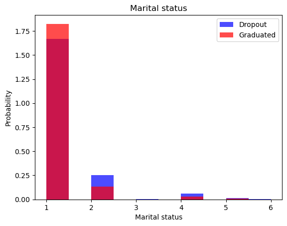

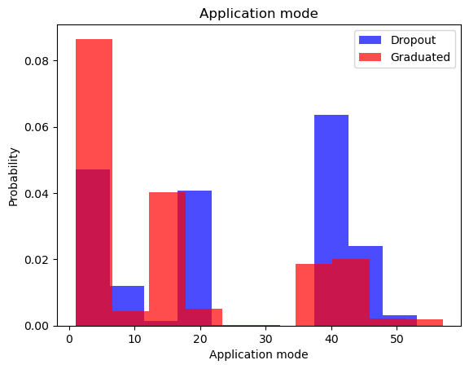

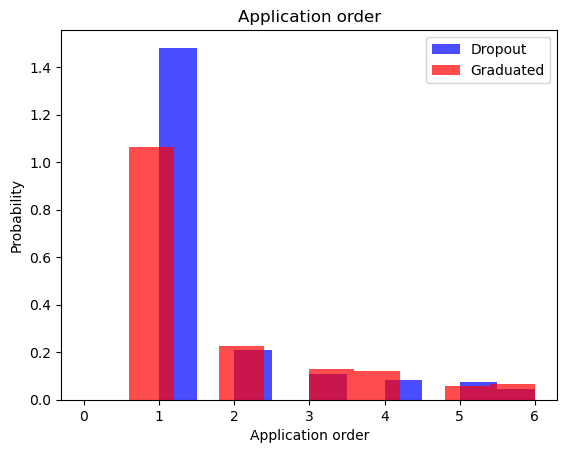

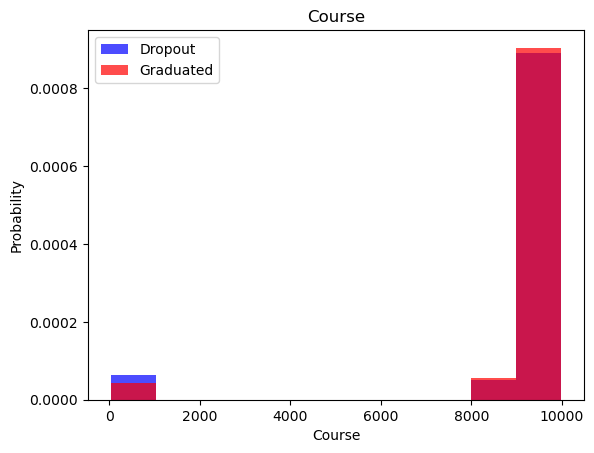

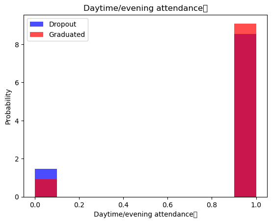

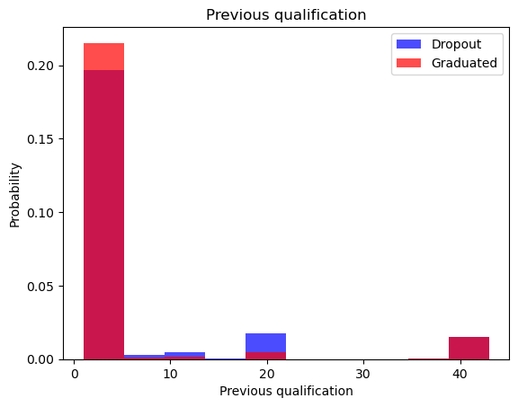

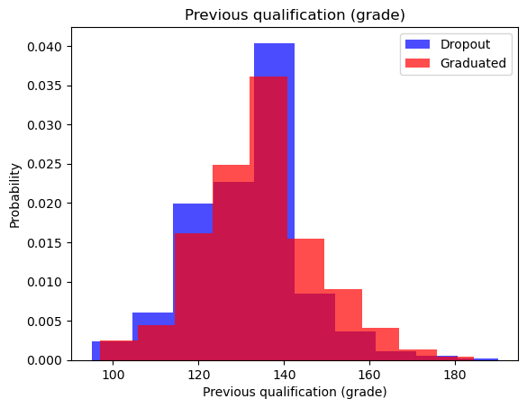

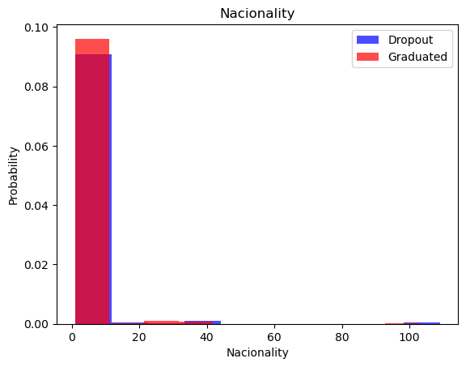

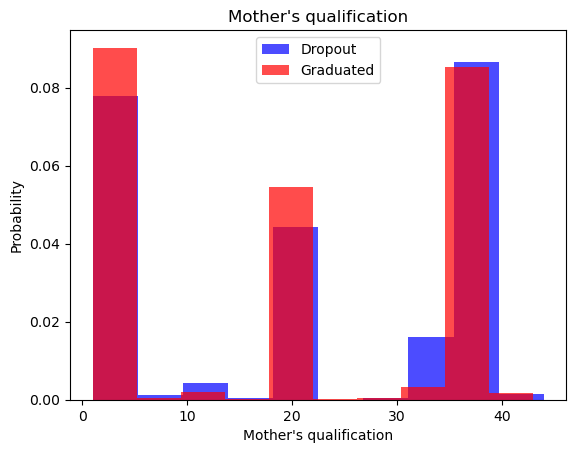

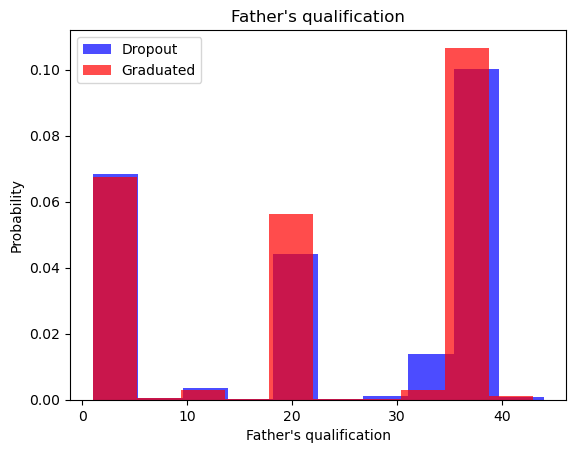

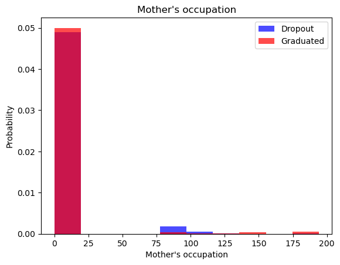

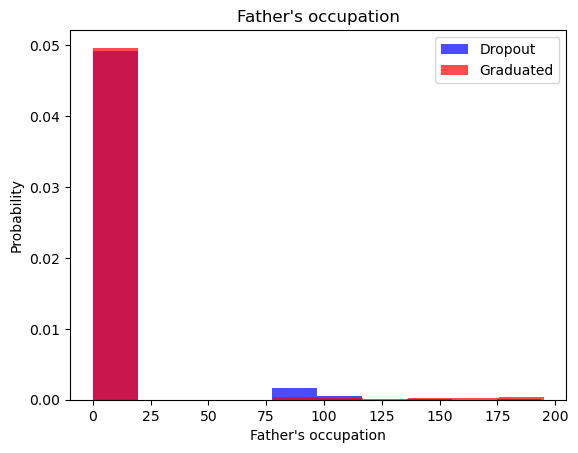

[24 more figures not shown]

```python
for label in df.columns[:-1]:
    plt.hist(df[df['Target']==1][label], color = 'blue', label='Dropout', alpha=0.7, density=True)
    plt.hist(df[df['Target']==0][label], color = 'red', label='Graduated', alpha=0.7, density = True)
    plt.title(label)
    plt.ylabel('Probability')
    plt.xlabel(label)
    plt.legend()
    plt.show()
```

# Train, validation, test

```python
train, valid, test = np.split(df.sample(frac=1), [int(0.6*len(df)), int(0.8*len(df))]) #60% train, 20% valid, 20% test
```

```python
from sklearn.preprocessing import StandardScaler
```

```python
def scale_dataset(dataframe):
    X = dataframe[dataframe.columns[:-1]].values
    y = dataframe[dataframe.columns[-1]].values

    scaler = StandardScaler()
    X = scaler.fit_transform(X)

    data = np.hstack((X, np.reshape(y, (-1, 1))))
    return data, X, y
```

```python
train, X_train, y_train = scale_dataset(train)
```

```python
valid, X_valid, y_valid = scale_dataset(valid)
```

```python
test, X_test, y_test = scale_dataset(test)
```

```python
X_train.shape
```

```
(2178, 36)
```

```python
y_train.shape
```

```
(2178,)
```

```python
X_test.shape
```

```
(726, 36)
```

# knn

determining the class by its distance to data points

```python
from sklearn.neighbors import KNeighborsClassifier
```

```python
knn_model = KNeighborsClassifier(n_neighbors=1)
knn_model.fit(X_train, y_train)
```

```
KNeighborsClassifier(n_neighbors=1)
```

```python
y_pred = knn_model.predict(X_test)
```

```python
from sklearn.metrics import classification_report
```

```python
print(classification_report(y_test, y_pred))
```

```
              precision    recall  f1-score   support

           0       0.78      0.91      0.84       406
           1       0.85      0.67      0.75       320

    accuracy                           0.80       726
   macro avg       0.82      0.79      0.80       726
weighted avg       0.81      0.80      0.80       726
```

### Evaluate

The accuracy is quite good, but we can test out other models to find the best one.

# Naive Bayes

(A|B)*P(B)/P(A)

```python
from sklearn.naive_bayes import GaussianNB
```

```python
nb_model = GaussianNB()
nb_model = nb_model.fit(X_train, y_train)
```

```python
y_pred = nb_model.predict(X_test)
print(classification_report(y_test, y_pred))
```

```
              precision    recall  f1-score   support

           0       0.80      0.93      0.86       406
           1       0.89      0.70      0.79       320

    accuracy                           0.83       726
   macro avg       0.84      0.82      0.82       726
weighted avg       0.84      0.83      0.83       726
```

### Evaluate

# Logistic Regression

relationship between coefficients

```python
from sklearn.linear_model import LogisticRegression
```

```python
lg_model = LogisticRegression()
lg_model = lg_model.fit(X_train, y_train)
```

```python
y_pred = lg_model.predict(X_test)
print(classification_report(y_test, y_pred))
```

```
              precision    recall  f1-score   support

           0       0.86      0.97      0.91       406
           1       0.95      0.79      0.87       320

    accuracy                           0.89       726
   macro avg       0.91      0.88      0.89       726
weighted avg       0.90      0.89      0.89       726
```

### Evaluate

# SVM

draw a line to separate the two classes

```python
from sklearn.svm import SVC
```

```python
svm_model = SVC()
svm_model = svm_model.fit(X_train, y_train)
```

```python
y_pred = svm_model.predict(X_test)
print(classification_report(y_test, y_pred))
```

```
              precision    recall  f1-score   support

           0       0.82      0.98      0.90       406
           1       0.97      0.73      0.83       320

    accuracy                           0.87       726
   macro avg       0.90      0.86      0.87       726
weighted avg       0.89      0.87      0.87       726
```

### Evaluate

# Neutral Network

```python
#import tensorflow as tf
```

```python
#nn_model = tf.keras.Sequential([
    #tf.keras.layers.Dense(32, activation='relu', input_shape=(10,)),
    #tf.keras.layers.Dense(32, activation='relu'),
    #tf.keras.layers.Dense(1, activation='sigmoid')
#])

#nn_model.compile(optimizer=tf.keras.optimizers.Adam(0.001), loss='binary_crossentropy',
                 #metrics=['accuracy'])
```

```python
#training
#history = nn_model.fit(
    #X_train, y_train, epochs=100, batch_size=12, validation_split=0.2, verbose=0
#)
```

```python
#pip install torch torchvision
```

```python
import torch
```

```python
import torch.nn as nn
import torch.optim as optim
```

```python
class StudentNN(nn.Module):
    def __init__(self, input_dim):
        super(StudentNN, self).__init__()
        # Define the architecture
        self.fc1 = nn.Linear(input_dim, 128)  # First layer (input_dim is number of features)
        self.fc2 = nn.Linear(128, 64)         # Second layer
        self.fc3 = nn.Linear(64, 32)          # Third layer
        self.fc4 = nn.Linear(32, 1)           # Output layer (1 for dropout or graduation)
        self.relu = nn.ReLU()                 # ReLU activation
        self.sigmoid = nn.Sigmoid()           # Sigmoid for binary classification

    def forward(self, x):
        x = self.fc1(x)        # First layer
        x = self.relu(x)       # Apply ReLU activation
        x = self.fc2(x)        # Second layer
        x = self.relu(x)       # Apply ReLU activation
        x = self.fc3(x)        # Third layer
        x = self.relu(x)       # Apply ReLU activation
        x = self.fc4(x)        # Output layer
        x = self.sigmoid(x)    # Sigmoid activation (output probability)
        return x
```

```python
X_train_small = X_train[:1000]
y_train_small = y_train[:1000]
```

```python
X_train_small.shape
```

```
(1000, 36)
```

```python
y_test.shape
```

```
(726,)
```

```python
X_train_tensor = torch.tensor(X_train_small, dtype=torch.float32)
y_train_tensor = torch.tensor(y_train_small, dtype=torch.float32).view(-1, 1)
X_test_tensor = torch.tensor(X_test, dtype=torch.float32)
y_test_tensor = torch.tensor(y_test, dtype=torch.float32).view(-1, 1)
```

```python
# Initialize the model
model = StudentNN(input_dim=X_train.shape[1]) #X_train rows

# Loss function and optimizer
criterion = nn.BCELoss()  # Binary Cross Entropy loss for binary classification
optimizer = optim.Adam(model.parameters(), lr=0.001)

# Training loop
num_epochs = 100
for epoch in range(num_epochs):
    model.train()  # Set the model to training mode
    optimizer.zero_grad()  # Clear previous gradients

    # Forward pass
    outputs = model(X_train_tensor)

    # Compute loss
    loss = criterion(outputs, y_train_tensor)

    # Backward pass (compute gradients)
    loss.backward()

    # Update model parameters
    optimizer.step()

    if (epoch + 1) % 10 == 0:  # Print loss every 10 epochs
        print(f"Epoch [{epoch+1}/{num_epochs}], Loss: {loss.item():.4f}")
```

[output not shown]

```python
model.eval()  # Set model to evaluation mode (disables dropout, batch norm, etc.)
with torch.no_grad():  # Disable gradient calculation for testing
    # Forward pass on test data
    outputs = model(X_test_tensor)

    # Convert outputs to predicted class (0 or 1)
    predicted = (outputs > 0.5).float()  # Sigmoid output > 0.5 means predicted 1, else 0

    # Calculate accuracy
    accuracy = (predicted == y_test_tensor).sum().item() / y_test_tensor.size(0)
    print(f'Accuracy on test data: {accuracy * 100:.2f}%')
```

[output not shown]

# Based on the models, it seems like logistic model is the best fit since it has the highest accuracy, precision, and recall scores.

```python
# Saving the model

import joblib
scaler = StandardScaler()
```

```python
# Save the model to a file
joblib.dump(lg_model, 'logistic_regression_model.pkl')

# Optionally, save the scaler as well if you used it for scaling features
joblib.dump(scaler, 'scaler.pkl')
```

```
['scaler.pkl']
```

```python
# Load the saved model
model = joblib.load('logistic_regression_model.pkl')

# Load the scaler (if applicable)
scaler = joblib.load('scaler.pkl')

# Assume you have new data for prediction (let's call it X_new)
# Don't forget to scale the new data the same way as the training data
X_new_scaled = scaler.transform(X_new)

# Make predictions using the loaded model
predictions = model.predict(X_new_scaled)

# If you want probability predictions (in case you're working with classification probabilities)
probabilities = model.predict_proba(X_new_scaled)
```